# Evaluación Interactiva de Matemáticas ICFES

Un experimento consiste en medir la elongación de un resorte en función de la fuerza aplicada. En la gráfica se registran los resultados de 100 mediciones realizadas con el mismo resorte.

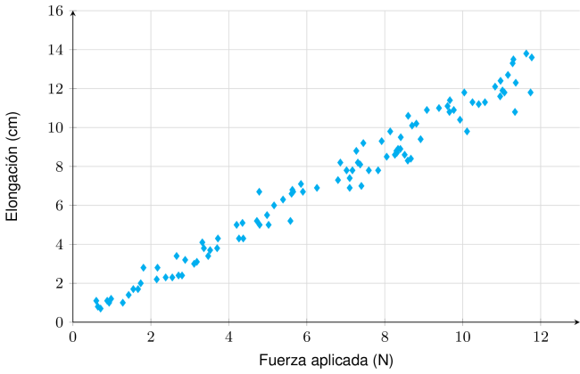

El comportamiento de la elongación respecto a la fuerza aplicada es

no proporcional y con mayor variabilidad cuanto mayor sea la fuerza aplicada.no proporcional y con mayor variabilidad cuanto mayor sea la deformación.de tipo lineal y con mayor variabilidad cuanto mayor sea la deformación.de tipo lineal y con mayor variabilidad cuanto mayor sea la fuerza aplicada.

Para analizar el comportamiento de la elongación respecto a la fuerza aplicada, debemos observar dos aspectos clave en la gráfica de dispersión:

**1. Tipo de relación (de tipo lineal vs no proporcional):**

La relación entre la fuerza y la elongación sigue la Ley de Hooke:

$$x = \frac{F}{k}$$

donde $x$ es la elongación, $F$ es la fuerza aplicada y $k$ es la constante del resorte. Esta es una función **de tipo lineal** (proporcionalidad directa). En la gráfica se observa claramente una tendencia rectilínea ascendente.

**2. Patrón de dispersión:**

Observando la gráfica:

- En elongaciones pequeñas (cercanas a 0 cm): los puntos están más concentrados
- En elongaciones grandes (cercanas a 12-14 cm): los puntos muestran mayor variabilidad

Esto indica que **la dispersión es proporcional a la deformación**, no a la fuerza aplicada. Físicamente, esto se explica porque los errores de medición se acumulan en elongaciones mayores, y además el resorte puede presentar pequeñas irregularidades cuando está muy estirado.

**Conclusión:**

El comportamiento es **de tipo lineal** (Ley de Hooke) y **con mayor variabilidad cuanto mayor sea la deformación** (mayor variabilidad en elongaciones grandes).

- **Falso**. La relación NO es no proporcional (es de tipo lineal según la Ley de Hooke).
- **Falso**. La relación NO es no proporcional (es de tipo lineal) y la dispersión NO aumenta con la deformación de forma no lineal.
- **Verdadero**. La relación es de tipo lineal (Ley de Hooke) y la dispersión aumenta proporcionalmente a la deformación.
- **Falso**. Aunque la relación es de tipo lineal, la dispersión NO aumenta con la fuerza aplicada sino con la deformación.

Un experimento consiste en medir la elongación de un resorte en función de la fuerza aplicada. En la gráfica se registran los resultados de 95 mediciones realizadas con el mismo resorte.

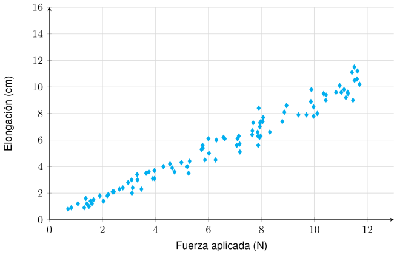

El comportamiento de la elongación respecto a la fuerza aplicada es

no proporcional y más variable cuanto mayor sea la carga.no proporcional y más variable cuanto mayor sea la elongación.proporcional y más variable cuanto mayor sea la elongación.proporcional y más variable cuanto mayor sea la carga.

Para analizar el comportamiento de la elongación respecto a la fuerza aplicada, debemos observar dos aspectos clave en la gráfica de dispersión:

**1. Tipo de relación (proporcional vs no proporcional):**

La relación entre la fuerza y la elongación sigue la Ley de Hooke:

$$x = \frac{F}{k}$$

donde $x$ es la elongación, $F$ es la fuerza aplicada y $k$ es la constante del resorte. Esta es una función **proporcional** (proporcionalidad directa). En la gráfica se observa claramente una tendencia rectilínea ascendente.

**2. Patrón de dispersión:**

Esto indica que **la dispersión es proporcional a la elongación**, no a la carga. Físicamente, esto se explica porque los errores de medición se acumulan en elongaciones mayores, y además el resorte puede presentar pequeñas irregularidades cuando está muy estirado.

**Conclusión:**

El comportamiento es **proporcional** (Ley de Hooke) y **más variable cuanto mayor sea la elongación** (mayor variabilidad en elongaciones grandes).

- **Falso**. La relación NO es no proporcional (es proporcional según la Ley de Hooke).
- **Falso**. La relación NO es no proporcional (es proporcional) y la dispersión NO aumenta con la elongación de forma no lineal.
- **Verdadero**. La relación es proporcional (Ley de Hooke) y la dispersión aumenta proporcionalmente a la elongación.
- **Falso**. Aunque la relación es proporcional, la dispersión NO aumenta con la carga sino con la elongación.

Un experimento consiste en medir la elongación de un resorte en función de la fuerza aplicada. En la gráfica se registran los resultados de 107 mediciones realizadas con el mismo resorte.

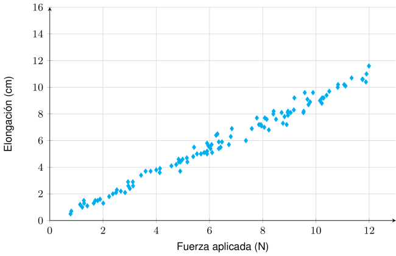

El comportamiento de la elongación respecto a la fuerza aplicada es

de tipo lineal y más disperso cuanto mayor sea la fuerza ejercida.no proporcional y más disperso cuanto mayor sea la deformación.no proporcional y más disperso cuanto mayor sea la fuerza ejercida.de tipo lineal y más disperso cuanto mayor sea la deformación.

Para analizar el comportamiento de la elongación respecto a la fuerza aplicada, debemos observar dos aspectos clave en la gráfica de dispersión:

**1. Tipo de relación (de tipo lineal vs no proporcional):**

La relación entre la fuerza y la elongación sigue la Ley de Hooke:

$$x = \frac{F}{k}$$

donde $x$ es la elongación, $F$ es la fuerza aplicada y $k$ es la constante del resorte. Esta es una función **de tipo lineal** (proporcionalidad directa). En la gráfica se observa claramente una tendencia rectilínea ascendente.

**2. Patrón de dispersión:**

Esto indica que **la dispersión es proporcional a la deformación**, no a la fuerza ejercida. Físicamente, esto se explica porque los errores de medición se acumulan en elongaciones mayores, y además el resorte puede presentar pequeñas irregularidades cuando está muy estirado.

**Conclusión:**

El comportamiento es **de tipo lineal** (Ley de Hooke) y **más disperso cuanto mayor sea la deformación** (mayor variabilidad en elongaciones grandes).

- **Falso**. Aunque la relación es de tipo lineal, la dispersión NO aumenta con la fuerza ejercida sino con la deformación.
- **Falso**. La relación NO es no proporcional (es de tipo lineal) y la dispersión NO aumenta con la deformación de forma no lineal.
- **Falso**. La relación NO es no proporcional (es de tipo lineal según la Ley de Hooke).
- **Verdadero**. La relación es de tipo lineal (Ley de Hooke) y la dispersión aumenta proporcionalmente a la deformación.

Un experimento consiste en medir la elongación de un resorte en función de la fuerza aplicada. En la gráfica se registran los resultados de 108 mediciones realizadas con el mismo resorte.

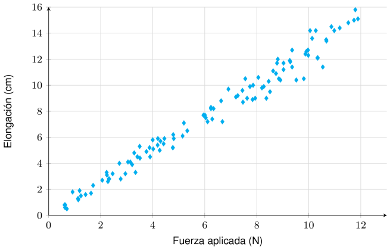

El comportamiento de la elongación respecto a la fuerza aplicada es

de tipo lineal y más disperso cuanto mayor sea la carga.cuadrático y más disperso cuanto mayor sea la carga.de tipo lineal y más disperso cuanto mayor sea la elongación del resorte.cuadrático y más disperso cuanto mayor sea la elongación del resorte.

Para analizar el comportamiento de la elongación respecto a la fuerza aplicada, debemos observar dos aspectos clave en la gráfica de dispersión:

**1. Tipo de relación (de tipo lineal vs cuadrático):**

La relación entre la fuerza y la elongación sigue la Ley de Hooke:

$$x = \frac{F}{k}$$

donde $x$ es la elongación, $F$ es la fuerza aplicada y $k$ es la constante del resorte. Esta es una función **de tipo lineal** (proporcionalidad directa). En la gráfica se observa claramente una tendencia rectilínea ascendente.

**2. Patrón de dispersión:**

Observando la gráfica:

- En elongaciones pequeñas (cercanas a 0 cm): los puntos están más concentrados
- En elongaciones grandes (cercanas a 12-14 cm): los puntos muestran mayor variabilidad

Esto indica que **la dispersión es proporcional a la elongación del resorte**, no a la carga. Físicamente, esto se explica porque los errores de medición se acumulan en elongaciones mayores, y además el resorte puede presentar pequeñas irregularidades cuando está muy estirado.

**Conclusión:**

El comportamiento es **de tipo lineal** (Ley de Hooke) y **más disperso cuanto mayor sea la elongación del resorte** (mayor variabilidad en elongaciones grandes).

- **Falso**. Aunque la relación es de tipo lineal, la dispersión NO aumenta con la carga sino con la elongación del resorte.
- **Falso**. La relación NO es cuadrático (es de tipo lineal según la Ley de Hooke).
- **Verdadero**. La relación es de tipo lineal (Ley de Hooke) y la dispersión aumenta proporcionalmente a la elongación del resorte.
- **Falso**. La relación NO es cuadrático (es de tipo lineal) y la dispersión NO aumenta con la elongación del resorte de forma no lineal.

Un experimento consiste en medir la elongación de un resorte en función de la fuerza aplicada. En la gráfica se registran los resultados de 100 mediciones realizadas con el mismo resorte.

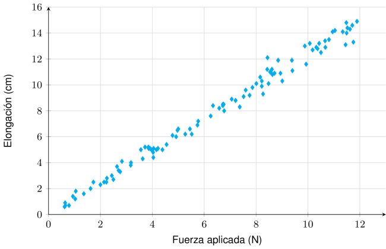

El comportamiento de la elongación respecto a la fuerza aplicada es

lineal y con mayor dispersión cuanto mayor sea la carga.lineal y con mayor dispersión cuanto mayor sea la elongación.no proporcional y con mayor dispersión cuanto mayor sea la carga.no proporcional y con mayor dispersión cuanto mayor sea la elongación.

Para analizar el comportamiento de la elongación respecto a la fuerza aplicada, debemos observar dos aspectos clave en la gráfica de dispersión:

**1. Tipo de relación (lineal vs no proporcional):**

La relación entre la fuerza y la elongación sigue la Ley de Hooke:

$$x = \frac{F}{k}$$

donde $x$ es la elongación, $F$ es la fuerza aplicada y $k$ es la constante del resorte. Esta es una función **lineal** (proporcionalidad directa). En la gráfica se observa claramente una tendencia rectilínea ascendente.

**2. Patrón de dispersión:**

Observando la gráfica:

- En elongaciones pequeñas (cercanas a 0 cm): los puntos están más concentrados
- En elongaciones grandes (cercanas a 12-14 cm): los puntos muestran mayor variabilidad

Esto indica que **la dispersión es proporcional a la elongación**, no a la carga. Físicamente, esto se explica porque los errores de medición se acumulan en elongaciones mayores, y además el resorte puede presentar pequeñas irregularidades cuando está muy estirado.

**Conclusión:**

El comportamiento es **lineal** (Ley de Hooke) y **con mayor dispersión cuanto mayor sea la elongación** (mayor variabilidad en elongaciones grandes).

- **Falso**. Aunque la relación es lineal, la dispersión NO aumenta con la carga sino con la elongación.
- **Verdadero**. La relación es lineal (Ley de Hooke) y la dispersión aumenta proporcionalmente a la elongación.
- **Falso**. La relación NO es no proporcional (es lineal según la Ley de Hooke).
- **Falso**. La relación NO es no proporcional (es lineal) y la dispersión NO aumenta con la elongación de forma no lineal.

Un experimento consiste en medir la elongación de un resorte en función de la fuerza aplicada. En la gráfica se registran los resultados de 95 mediciones realizadas con el mismo resorte.

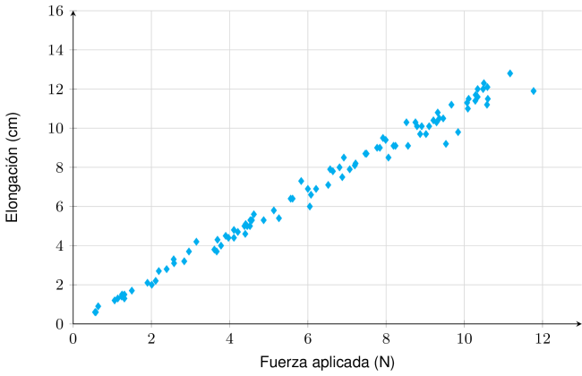

El comportamiento de la elongación respecto a la fuerza aplicada es

directamente proporcional y con mayor variabilidad cuanto mayor sea la elongación.cuadrático y con mayor variabilidad cuanto mayor sea la elongación.directamente proporcional y con mayor variabilidad cuanto mayor sea la fuerza.cuadrático y con mayor variabilidad cuanto mayor sea la fuerza.

Para analizar el comportamiento de la elongación respecto a la fuerza aplicada, debemos observar dos aspectos clave en la gráfica de dispersión:

**1. Tipo de relación (directamente proporcional vs cuadrático):**

La relación entre la fuerza y la elongación sigue la Ley de Hooke:

$$x = \frac{F}{k}$$

donde $x$ es la elongación, $F$ es la fuerza aplicada y $k$ es la constante del resorte. Esta es una función **directamente proporcional** (proporcionalidad directa). En la gráfica se observa claramente una tendencia rectilínea ascendente.

**2. Patrón de dispersión:**

Observando la gráfica:

- En elongaciones pequeñas (cercanas a 0 cm): los puntos están más concentrados
- En elongaciones grandes (cercanas a 12-14 cm): los puntos muestran mayor variabilidad

Esto indica que **la dispersión es proporcional a la elongación**, no a la fuerza. Físicamente, esto se explica porque los errores de medición se acumulan en elongaciones mayores, y además el resorte puede presentar pequeñas irregularidades cuando está muy estirado.

**Conclusión:**

El comportamiento es **directamente proporcional** (Ley de Hooke) y **con mayor variabilidad cuanto mayor sea la elongación** (mayor variabilidad en elongaciones grandes).

- **Verdadero**. La relación es directamente proporcional (Ley de Hooke) y la dispersión aumenta proporcionalmente a la elongación.
- **Falso**. La relación NO es cuadrático (es directamente proporcional) y la dispersión NO aumenta con la elongación de forma no lineal.
- **Falso**. Aunque la relación es directamente proporcional, la dispersión NO aumenta con la fuerza sino con la elongación.
- **Falso**. La relación NO es cuadrático (es directamente proporcional según la Ley de Hooke).

Un experimento consiste en medir la elongación de un resorte en función de la fuerza aplicada. En la gráfica se registran los resultados de 96 mediciones realizadas con el mismo resorte.

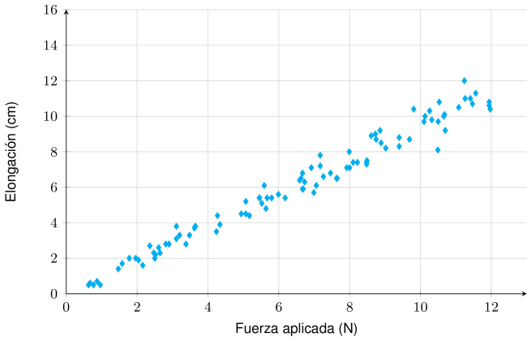

El comportamiento de la elongación respecto a la fuerza aplicada es

no lineal y más variable cuanto mayor sea la deformación.directamente proporcional y más variable cuanto mayor sea la fuerza ejercida.directamente proporcional y más variable cuanto mayor sea la deformación.no lineal y más variable cuanto mayor sea la fuerza ejercida.

Para analizar el comportamiento de la elongación respecto a la fuerza aplicada, debemos observar dos aspectos clave en la gráfica de dispersión:

**1. Tipo de relación (directamente proporcional vs no lineal):**

La relación entre la fuerza y la elongación sigue la Ley de Hooke:

$$x = \frac{F}{k}$$

donde $x$ es la elongación, $F$ es la fuerza aplicada y $k$ es la constante del resorte. Esta es una función **directamente proporcional** (proporcionalidad directa). En la gráfica se observa claramente una tendencia rectilínea ascendente.

**2. Patrón de dispersión:**

Observando la gráfica:

- En elongaciones pequeñas (cercanas a 0 cm): los puntos están más concentrados
- En elongaciones grandes (cercanas a 12-14 cm): los puntos muestran mayor variabilidad

Esto indica que **la dispersión es proporcional a la deformación**, no a la fuerza ejercida. Físicamente, esto se explica porque los errores de medición se acumulan en elongaciones mayores, y además el resorte puede presentar pequeñas irregularidades cuando está muy estirado.

**Conclusión:**

El comportamiento es **directamente proporcional** (Ley de Hooke) y **más variable cuanto mayor sea la deformación** (mayor variabilidad en elongaciones grandes).

- **Falso**. La relación NO es no lineal (es directamente proporcional) y la dispersión NO aumenta con la deformación de forma no lineal.
- **Falso**. Aunque la relación es directamente proporcional, la dispersión NO aumenta con la fuerza ejercida sino con la deformación.
- **Verdadero**. La relación es directamente proporcional (Ley de Hooke) y la dispersión aumenta proporcionalmente a la deformación.
- **Falso**. La relación NO es no lineal (es directamente proporcional según la Ley de Hooke).

Un experimento consiste en medir la elongación de un resorte en función de la fuerza aplicada. En la gráfica se registran los resultados de 92 mediciones realizadas con el mismo resorte.

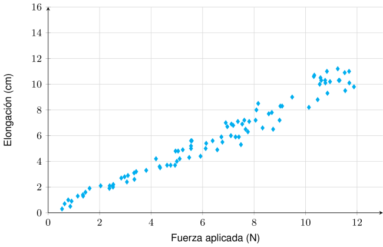

El comportamiento de la elongación respecto a la fuerza aplicada es

de tipo lineal y con mayor dispersión cuanto mayor sea la carga.de tipo lineal y con mayor dispersión cuanto mayor sea la deformación.cuadrático y con mayor dispersión cuanto mayor sea la carga.cuadrático y con mayor dispersión cuanto mayor sea la deformación.

Para analizar el comportamiento de la elongación respecto a la fuerza aplicada, debemos observar dos aspectos clave en la gráfica de dispersión:

**1. Tipo de relación (de tipo lineal vs cuadrático):**

La relación entre la fuerza y la elongación sigue la Ley de Hooke:

$$x = \frac{F}{k}$$

donde $x$ es la elongación, $F$ es la fuerza aplicada y $k$ es la constante del resorte. Esta es una función **de tipo lineal** (proporcionalidad directa). En la gráfica se observa claramente una tendencia rectilínea ascendente.

**2. Patrón de dispersión:**

Esto indica que **la dispersión es proporcional a la deformación**, no a la carga. Físicamente, esto se explica porque los errores de medición se acumulan en elongaciones mayores, y además el resorte puede presentar pequeñas irregularidades cuando está muy estirado.

**Conclusión:**

El comportamiento es **de tipo lineal** (Ley de Hooke) y **con mayor dispersión cuanto mayor sea la deformación** (mayor variabilidad en elongaciones grandes).

- **Falso**. Aunque la relación es de tipo lineal, la dispersión NO aumenta con la carga sino con la deformación.
- **Verdadero**. La relación es de tipo lineal (Ley de Hooke) y la dispersión aumenta proporcionalmente a la deformación.
- **Falso**. La relación NO es cuadrático (es de tipo lineal según la Ley de Hooke).
- **Falso**. La relación NO es cuadrático (es de tipo lineal) y la dispersión NO aumenta con la deformación de forma no lineal.

Un experimento consiste en medir la elongación de un resorte en función de la fuerza aplicada. En la gráfica se registran los resultados de 105 mediciones realizadas con el mismo resorte.

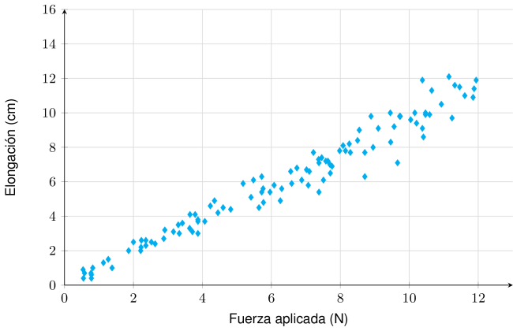

El comportamiento de la elongación respecto a la fuerza aplicada es

directamente proporcional y más disperso cuanto mayor sea el estiramiento.cuadrático y más disperso cuanto mayor sea el estiramiento.cuadrático y más disperso cuanto mayor sea la carga.directamente proporcional y más disperso cuanto mayor sea la carga.

Para analizar el comportamiento de la elongación respecto a la fuerza aplicada, debemos observar dos aspectos clave en la gráfica de dispersión:

**1. Tipo de relación (directamente proporcional vs cuadrático):**

La relación entre la fuerza y la elongación sigue la Ley de Hooke:

$$x = \frac{F}{k}$$

donde $x$ es la elongación, $F$ es la fuerza aplicada y $k$ es la constante del resorte. Esta es una función **directamente proporcional** (proporcionalidad directa). En la gráfica se observa claramente una tendencia rectilínea ascendente.

**2. Patrón de dispersión:**

Observando la gráfica:

- En elongaciones pequeñas (cercanas a 0 cm): los puntos están más concentrados
- En elongaciones grandes (cercanas a 12-14 cm): los puntos muestran mayor variabilidad

Esto indica que **la dispersión es proporcional a el estiramiento**, no a la carga. Físicamente, esto se explica porque los errores de medición se acumulan en elongaciones mayores, y además el resorte puede presentar pequeñas irregularidades cuando está muy estirado.

**Conclusión:**

El comportamiento es **directamente proporcional** (Ley de Hooke) y **más disperso cuanto mayor sea el estiramiento** (mayor variabilidad en elongaciones grandes).

- **Verdadero**. La relación es directamente proporcional (Ley de Hooke) y la dispersión aumenta proporcionalmente a el estiramiento.
- **Falso**. La relación NO es cuadrático (es directamente proporcional) y la dispersión NO aumenta con el estiramiento de forma no lineal.
- **Falso**. La relación NO es cuadrático (es directamente proporcional según la Ley de Hooke).
- **Falso**. Aunque la relación es directamente proporcional, la dispersión NO aumenta con la carga sino con el estiramiento.

Un experimento consiste en medir la elongación de un resorte en función de la fuerza aplicada. En la gráfica se registran los resultados de 91 mediciones realizadas con el mismo resorte.

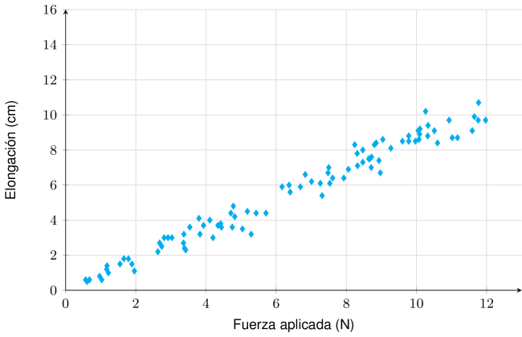

El comportamiento de la elongación respecto a la fuerza aplicada es

cuadrático y con mayor variabilidad cuanto mayor sea el estiramiento.cuadrático y con mayor variabilidad cuanto mayor sea la fuerza aplicada.directamente proporcional y con mayor variabilidad cuanto mayor sea el estiramiento.directamente proporcional y con mayor variabilidad cuanto mayor sea la fuerza aplicada.

Para analizar el comportamiento de la elongación respecto a la fuerza aplicada, debemos observar dos aspectos clave en la gráfica de dispersión:

**1. Tipo de relación (directamente proporcional vs cuadrático):**

La relación entre la fuerza y la elongación sigue la Ley de Hooke:

$$x = \frac{F}{k}$$

donde $x$ es la elongación, $F$ es la fuerza aplicada y $k$ es la constante del resorte. Esta es una función **directamente proporcional** (proporcionalidad directa). En la gráfica se observa claramente una tendencia rectilínea ascendente.

**2. Patrón de dispersión:**

Esto indica que **la dispersión es proporcional a el estiramiento**, no a la fuerza aplicada. Físicamente, esto se explica porque los errores de medición se acumulan en elongaciones mayores, y además el resorte puede presentar pequeñas irregularidades cuando está muy estirado.

**Conclusión:**

El comportamiento es **directamente proporcional** (Ley de Hooke) y **con mayor variabilidad cuanto mayor sea el estiramiento** (mayor variabilidad en elongaciones grandes).

- **Falso**. La relación NO es cuadrático (es directamente proporcional) y la dispersión NO aumenta con el estiramiento de forma no lineal.
- **Falso**. La relación NO es cuadrático (es directamente proporcional según la Ley de Hooke).
- **Verdadero**. La relación es directamente proporcional (Ley de Hooke) y la dispersión aumenta proporcionalmente a el estiramiento.
- **Falso**. Aunque la relación es directamente proporcional, la dispersión NO aumenta con la fuerza aplicada sino con el estiramiento.